# Pre-QUES

# Bagaimana Analisis Ini Bekerja?

1. **Peta tutupan lahan dari dua periode waktu**: Analisis perubahan lahan dimulai dengan membandingkan data peta tutupan lahan dari dua periode waktu yang berbeda. Ini memberikan gambaran tentang bagaimana lahan di suatu daerah berubah sepanjang waktu.
2. **Mengintegrasikan peta Unit Perencanaan**: Data unit perencanaan kemudian dimasukkan dalam proses ini. Ini memungkinkan kita untuk melihat kecenderungan perubahan tutupan lahan pada masing-masing kelas unit perencanaan.

# **Mengapa Analisis Ini Penting?**

Hasil dari analisis ini berperan penting dalam proses perencanaan untuk berbagai aspek pembangunan. Berikut adalah beberapa aplikasinya:

- **Menentukan Prioritas Pembangunan**: Dengan memahami pola dan tren perubahan lahan, kita bisa menentukan area mana yang harus diberi prioritas dalam pembangunan.
- **Mengidentifikasi Faktor Pemicu**: Analisis ini membantu kita dalam mengidentifikasi faktor pemicu yang mempengaruhi perubahan penggunaan lahan.
- **Perencanaan Skenario Masa Depan**: Memahami perubahan masa lalu dan saat ini memungkinkan kita untuk merencanakan skenario pembangunan masa depan.

# 1. Data yang digunakan

Berikut adalah komponen data yang digunakan dalam analisis perubahan lahan:

- **Peta Penggunaan Lahan**: Ini adalah sumber utama informasi yang menunjukkan pola dan distribusi penggunaan lahan di suatu area.
- **Peta Unit Perencanaan Daerah**: Sebagai petunjuk dari area perencanaan, peta ini digunakan untuk menunjukkan bagaimana lahan direncanakan untuk digunakan dan dikembangkan.
- **Tabel Acuan Tipe Penggunaan Lahan**: Tabel ini memberikan klasifikasi terperinci tentang berbagai tipe penggunaan lahan.
- **Tabel Acuan Kelas Unit Perencanaan**: Ini membantu kita memahami klasifikasi dan karakteristik dari unit-unit perencanaan yang berbeda.

```
#> SpatRaster resampled to ncells = 500820
```

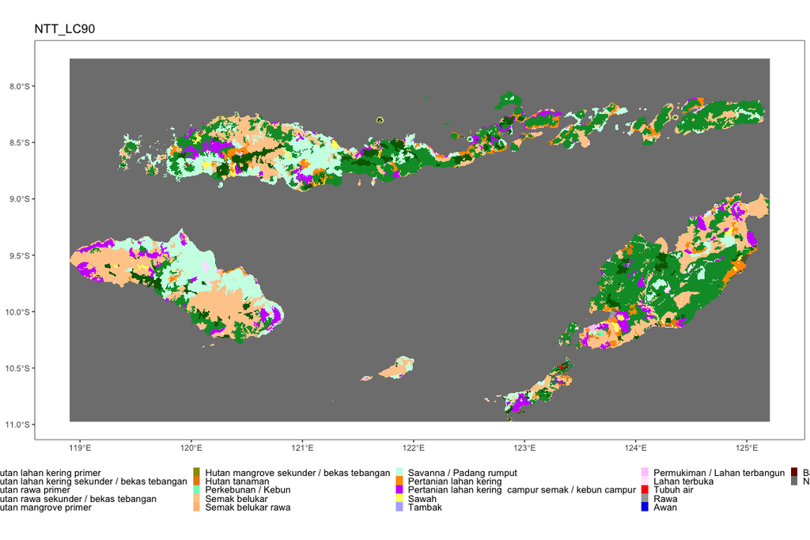

```
#> SpatRaster resampled to ncells = 500820
```

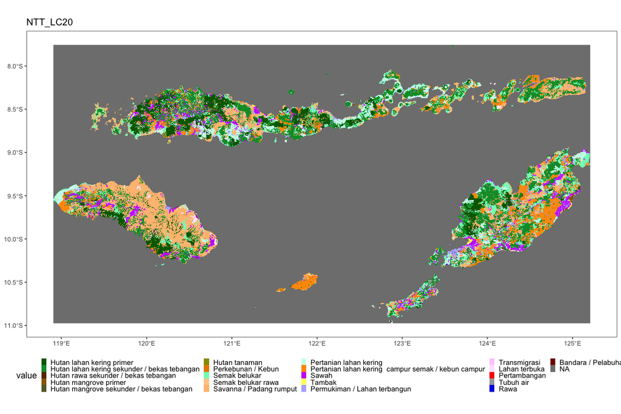

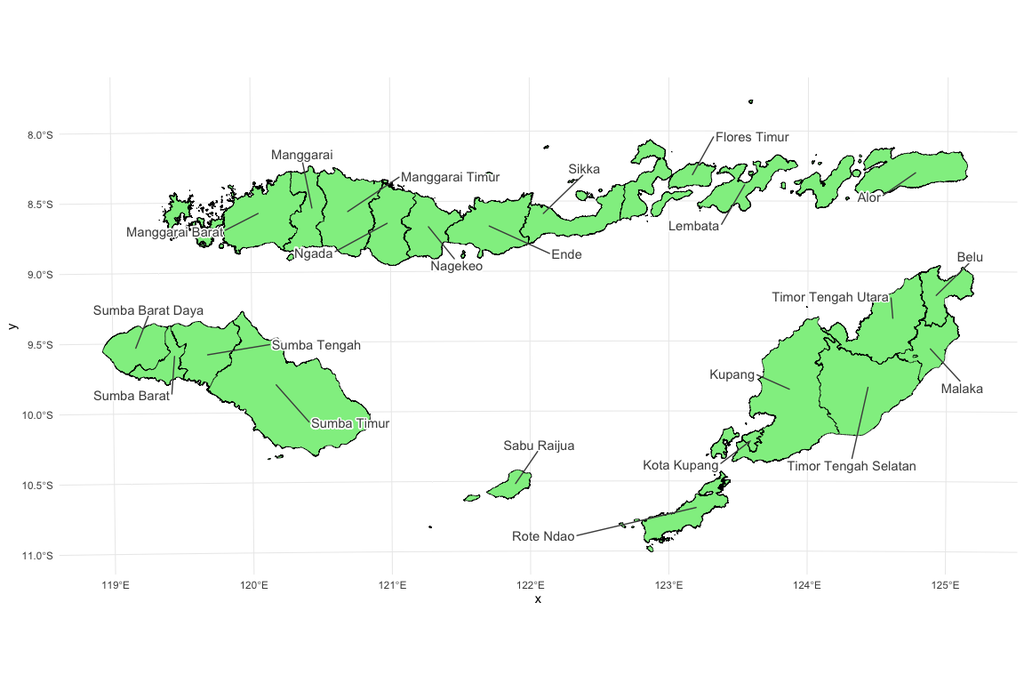

## Tabel deskripsi singkatan

| Value | PL20 | abbr |
| --- | --- | --- |
| 2001 | Hutan lahan kering primer | Htn_lhn_krng_prmr |
| 2002 | Hutan lahan kering sekunder / bekas tebangan | Htn_lhn_krng_skndr |
| 2005 | Hutan rawa primer | Htn_rw_prmr |
| 20051 | Hutan rawa sekunder / bekas tebangan | Htn_rw_skndr |
| 2004 | Hutan mangrove primer | Htn_mngrv_prmr |
| 20041 | Hutan mangrove sekunder / bekas tebangan | Htn_mngrv_skndr |
| 2006 | Hutan tanaman | Htn_tnmn |
| 2010 | Perkebunan / Kebun | Prkbnn |
| 2007 | Semak belukar | Smk_blkr |
| 20071 | Semak belukar rawa | Smk_blkr_rw |

[output cut: 13 more lines]

# 2. Hasil analisis pada tingkat bentang lahan

## Tabel kondisi tutupan lahan

| Jenis tutupan lahan | NTT_LC90_count | NTT_LC20_count |
| --- | --- | --- |
| Hutan lahan kering sekunder | 1600332 | 1124275 |
| Savanna | 841939 | 1042178 |
| Pertanian lahan kering campur semak | 316885 | 558507 |
| Hutan lahan kering primer | 266120 | 526439 |
| Semak belukar | 1215032 | 464107 |
| Pertanian lahan kering | 193602 | 345627 |
| Sawah | 52032 | 291646 |
| Permukiman | 33817 | 186733 |
| Tubuh air | 3189 | 29375 |
| Lahan terbuka | 53775 | 29242 |

[output cut: 11 more lines]

## Komposisi tutupan lahan

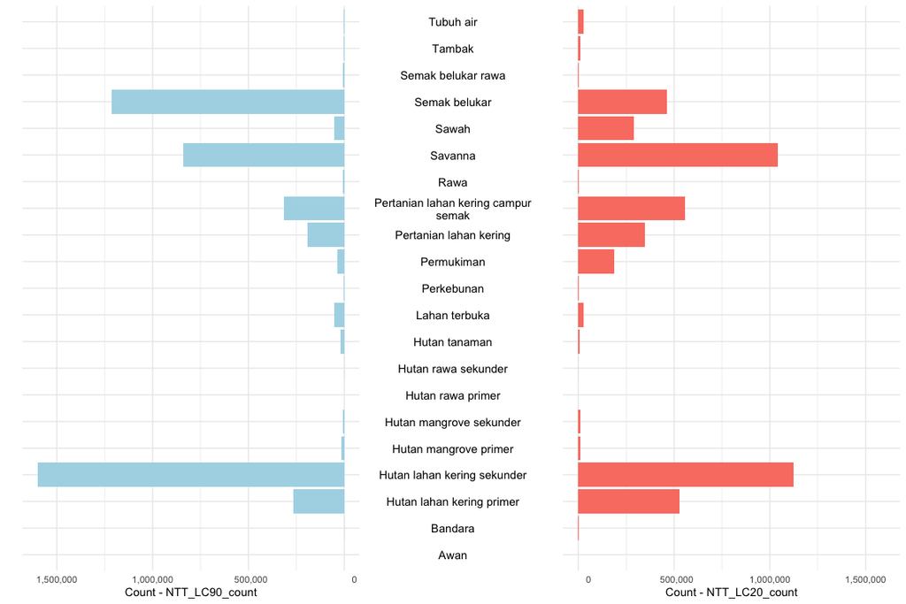

## Alur perubahan lahan dominan

### Komposisi tutupan dan perubahan tutupan lahan

[interactive chart not shown]

### Potret perubahan tutupan lahan

Tanpa mempertimbangkan tutupan lahan yang tidak berubah/ tetap.

[interactive chart not shown]

## 10 jenis perubahan dominan

### Dalam Tabel

| NTT_LC90 | NTT_LC20 | Freq |
| --- | --- | --- |
| Semak belukar | Savanna | 304940 |
| Semak belukar | Hutan lahan kering sekunder | 266735 |
| Hutan lahan kering sekunder | Hutan lahan kering primer | 232306 |
| Hutan lahan kering sekunder | Pertanian lahan kering campur semak | 219061 |
| Semak belukar | Pertanian lahan kering campur semak | 175650 |
| Hutan lahan kering sekunder | Semak belukar | 164067 |
| Hutan lahan kering sekunder | Savanna | 133818 |
| Semak belukar | Pertanian lahan kering | 96954 |
| Hutan lahan kering sekunder | Pertanian lahan kering | 81908 |
| Savanna | Hutan lahan kering sekunder | 79774 |

### Dalam grafik

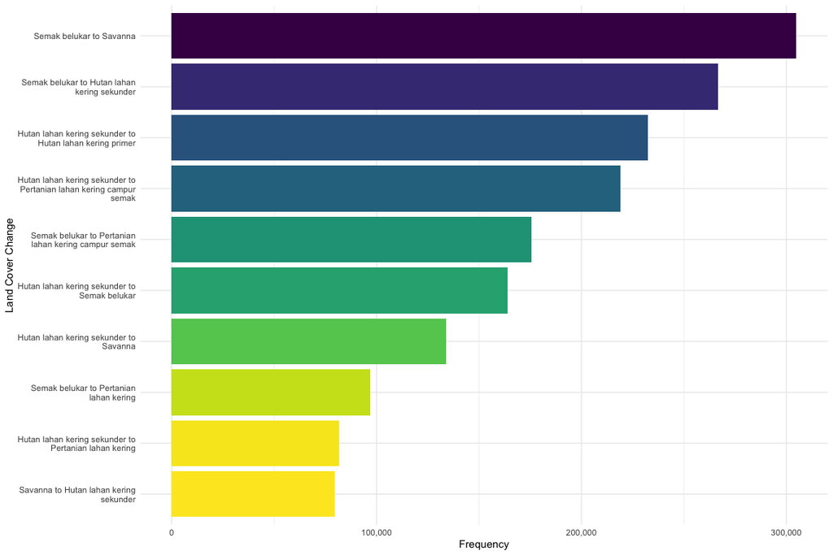